# Acoustic Surveys Report for German Bank and Seal Island areas

2023-11-09

# Acoustic Survey Tabs

## Summary Results

### Number of Surveys

Table 1. Summary of the number of surveys undertaken in 2020, and the number of surveys examined in the estimation of spawning stock biomass (SSB) for the Atlantic herring 4VWX stock and coastal component complexes. Numbers in brackets indicate the number of surveys excluded from total biomass estimates.

|  | Spawning Grounds | Number of Surveys | Notes |
| --- | --- | --- | --- |
| 1 | German Bank | 6 |  |
| 2 | Seal Island | 6 |  |
| 3 | Total | 12 |  |

| Spawning Grounds | Number of Surveys | Notes |
| --- | --- | --- |
| German Bank | 6 |  |
| Seal Island | 6 |  |
| Total | 12 |  |

### Survey Dates

Table 2. Summary of completed herring acoustic surveys in 2020 with interval (days) between surveys on the same grounds, and the number of boats with acoustic systems.

|  | Location of Survey | Survey Date | Interval (days) | Acoustic Boats |
| --- | --- | --- | --- | --- |
| 1 | German Bank #1 | 2020-08-16 |  | 6 |
| 2 | German Bank #2 | 2020-08-31 | 15 | 7 |
| 3 | German Bank #3 | 2020-09-13 | 13 | 7 |
| 4 | German Bank #4 | 2020-09-27 | 14 | 7 |
| 5 | German Bank #5 | 2020-10-11 | 14 | 7 |
| 6 | German Bank #6 | 2020-10-25 | 14 | 6 |
| 7 | Seal Island #1 | 2020-08-16 |  | 6 |
| 8 | Seal Island #2 | 2020-08-31 | 15 | 1 |
| 9 | Seal Island #3 | 2020-09-13 | 13 | 2 |
| 10 | Seal Island #4 | 2020-09-27 | 14 | 2 |

[output cut: 2 more lines]

| Location of Survey | Survey Date | Interval (days) | Acoustic Boats |
| --- | --- | --- | --- |
| German Bank #1 | 2020-08-16 | NA | 6 |
| German Bank #2 | 2020-08-31 | 15 | 7 |
| German Bank #3 | 2020-09-13 | 13 | 7 |
| German Bank #4 | 2020-09-27 | 14 | 7 |
| German Bank #5 | 2020-10-11 | 14 | 7 |
| German Bank #6 | 2020-10-25 | 14 | 6 |
| Seal Island #1 | 2020-08-16 | NA | 6 |
| Seal Island #2 | 2020-08-31 | 15 | 1 |
| Seal Island #3 | 2020-09-13 | 13 | 2 |
| Seal Island #4 | 2020-09-27 | 14 | 2 |
| Seal Island #5 | 2020-10-11 | 14 | 7 |
| Seal Island #6 | 2020-10-26 | 15 | 5 |

### SWNS/BoF Time-Series

Figure. Trends in herring SSB (adjusted for turnover) from acoustic surveys areas with 95% confidence intervals in Scots Bay (red) and German Bank (black) areas.

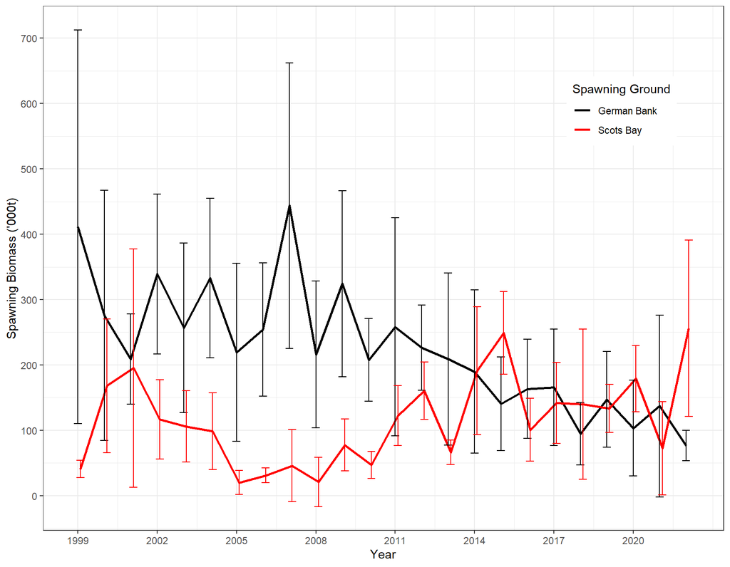

Figure. Acoustic index of SSB (in thousands of metric tons) (with 95% confidence intervals; black Line), the 3-year moving average (red line), the overall average since 1999 (dashed purple line), and the Limit Reference Point for the Southwest Nova Scotia/Bay of Fundy spawning component (revised 2005–2010 German Bank and Scots Bay average; dashed blue line).

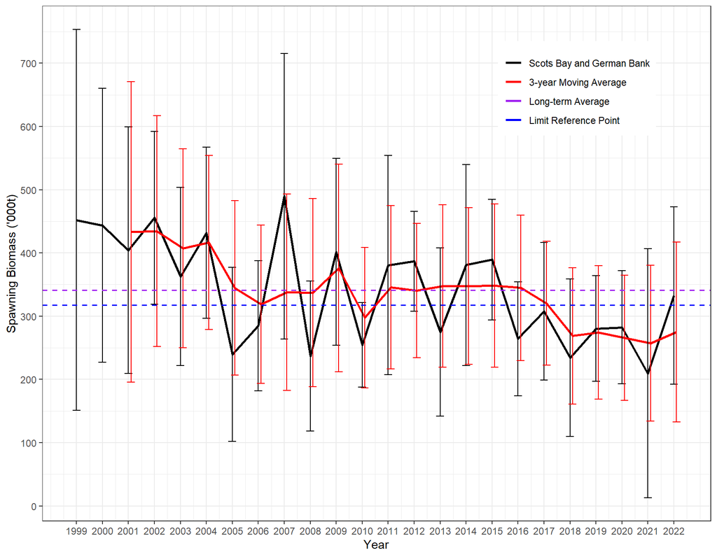

## German Bank

### Summary

Table. Summary of the 2020 German Bank spawning ground acoustic survey data and associated biomass estimates. Adjusted biomass numbers refer to adjustment for turnover.

[output not shown]

[output not shown]

### Area Plot

Figure. Plots of Transects and area buffer for each survey.

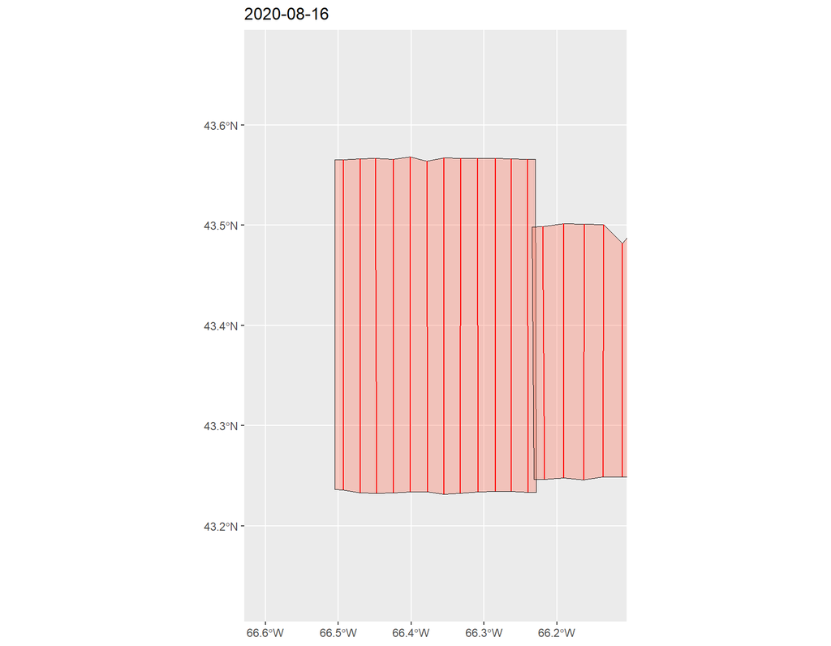

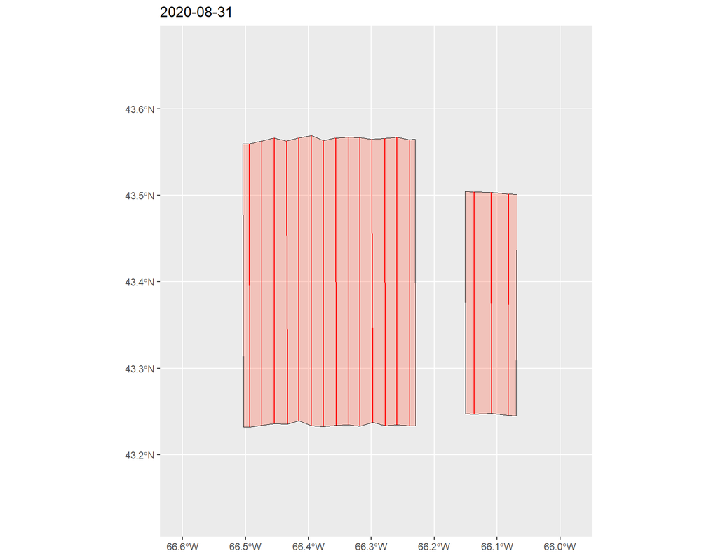

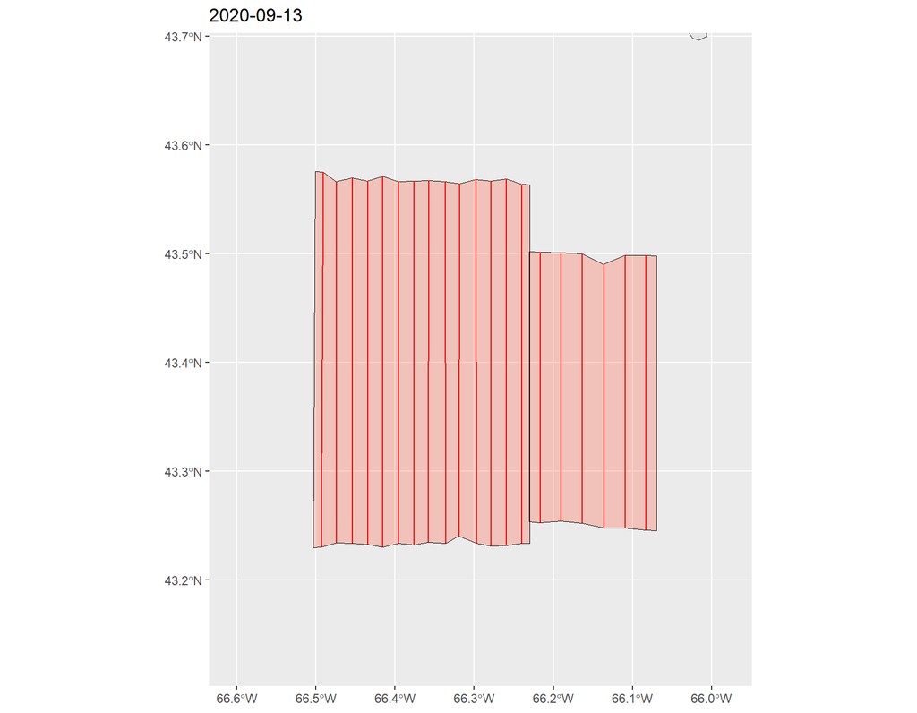

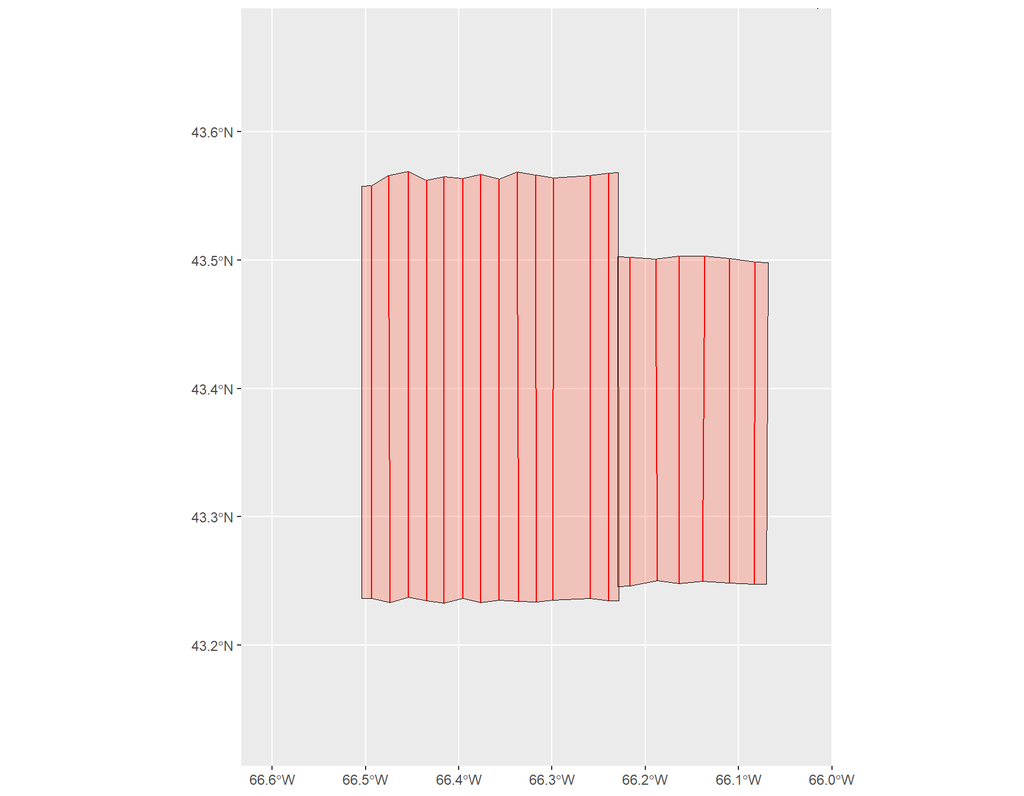

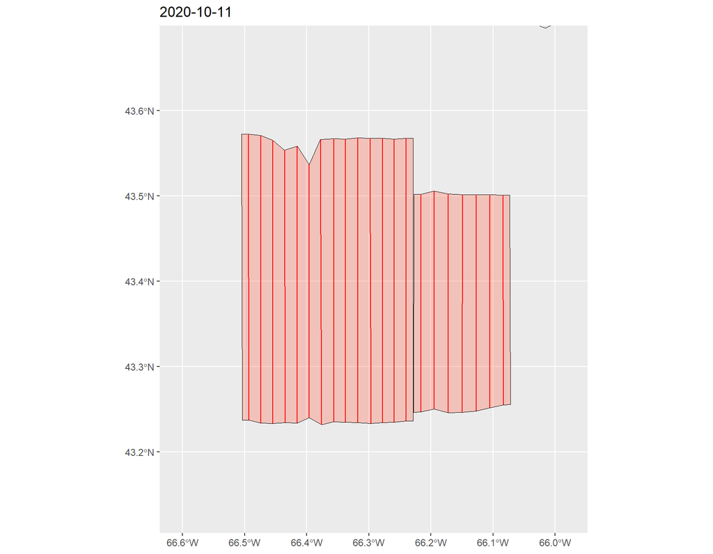

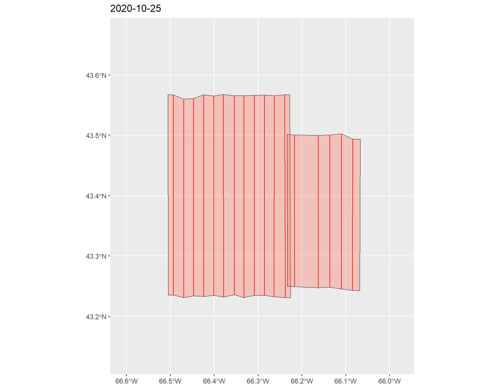

### Length Frequency

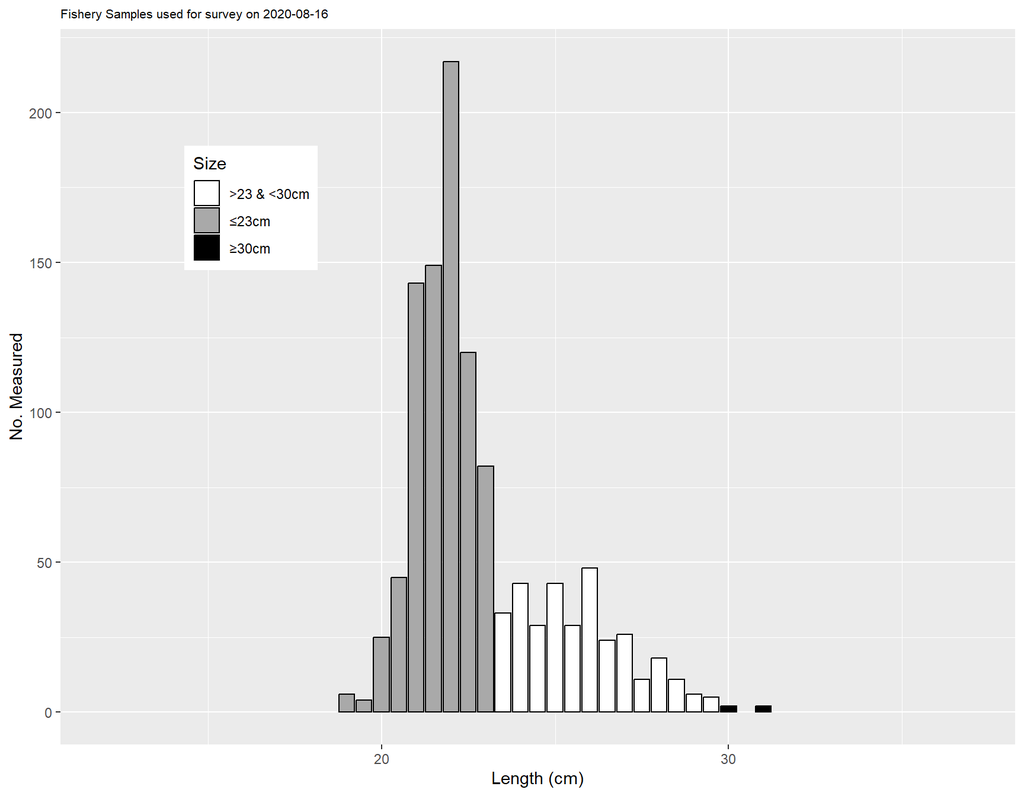

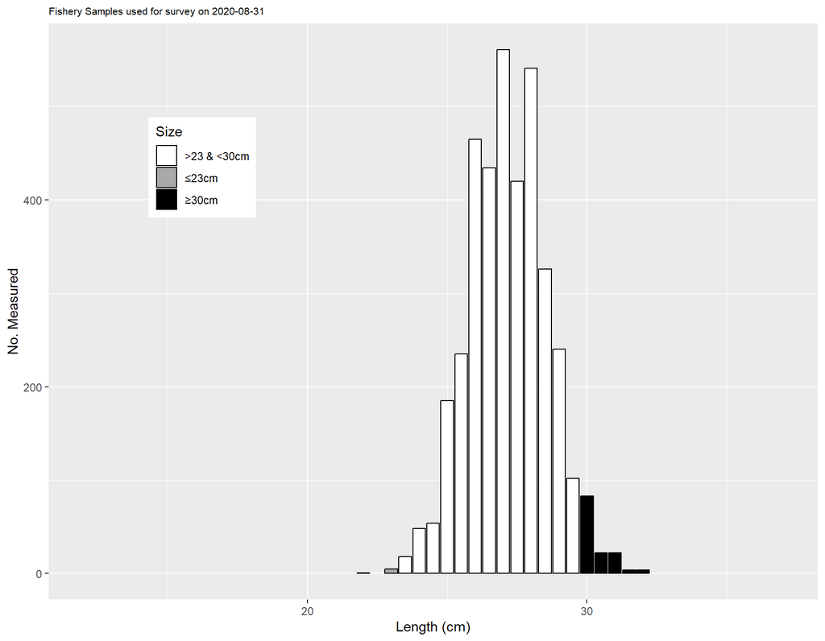

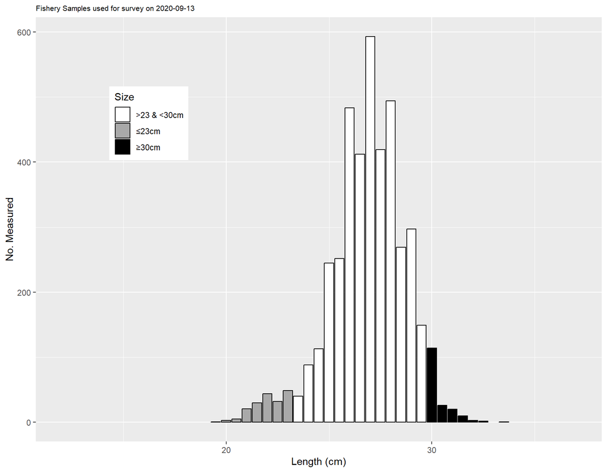

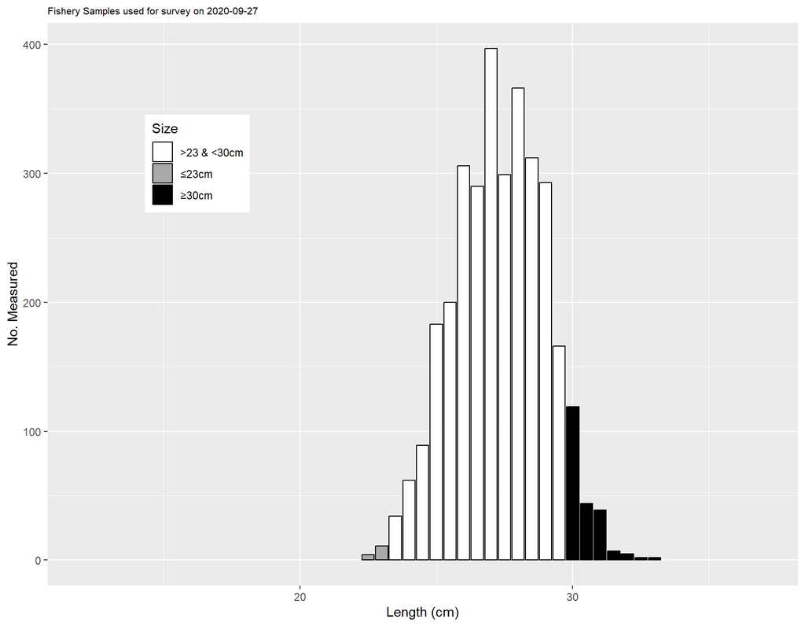

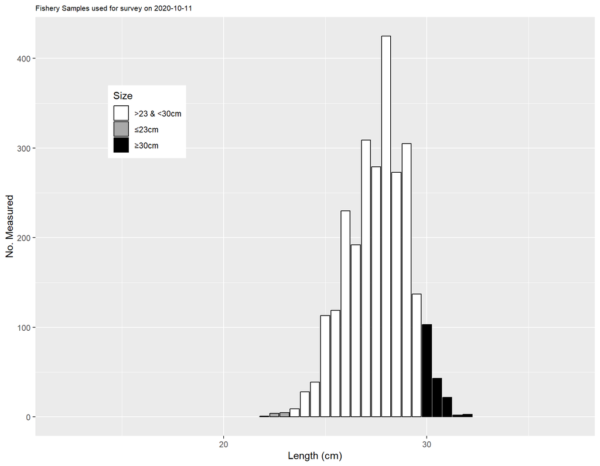

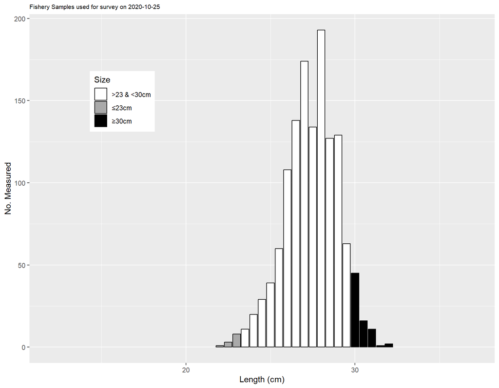

### Maturity Samples

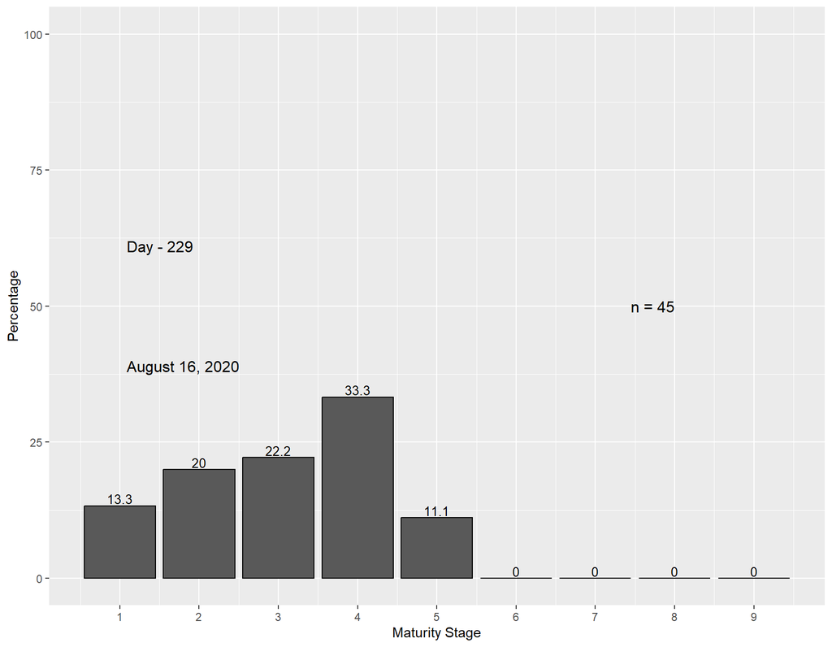

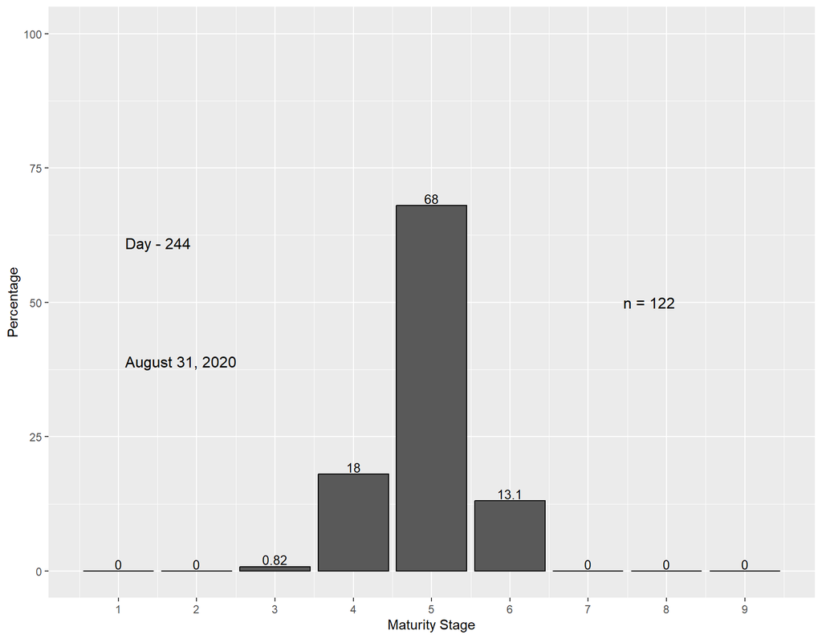

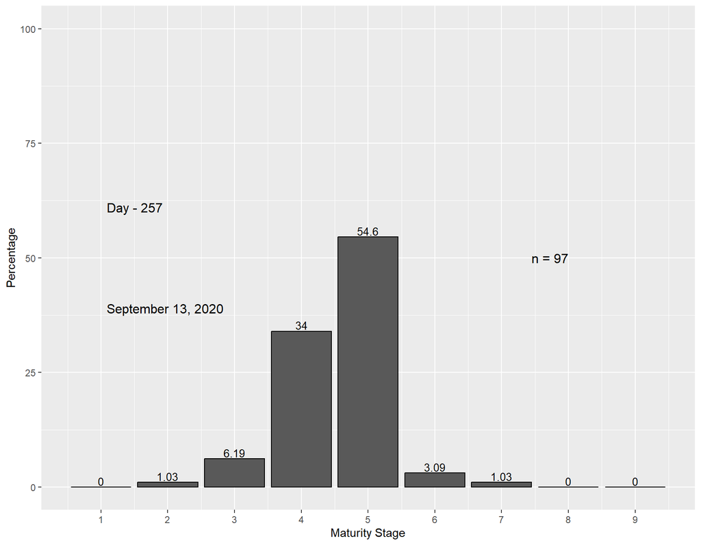

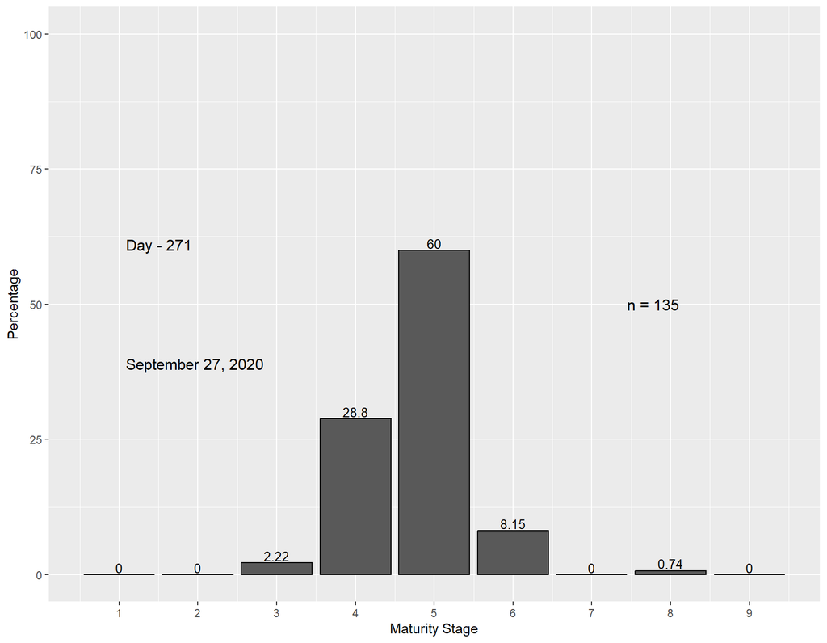

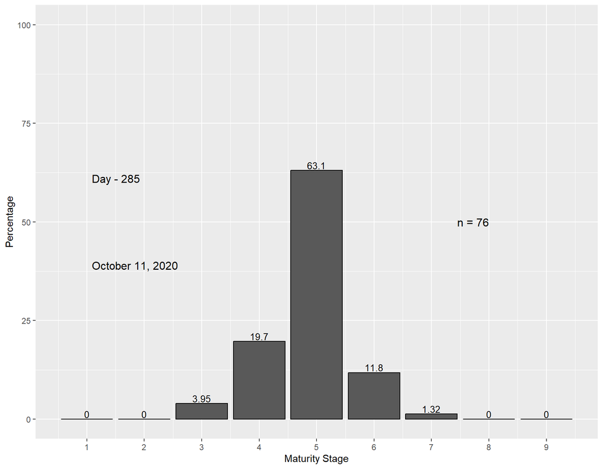

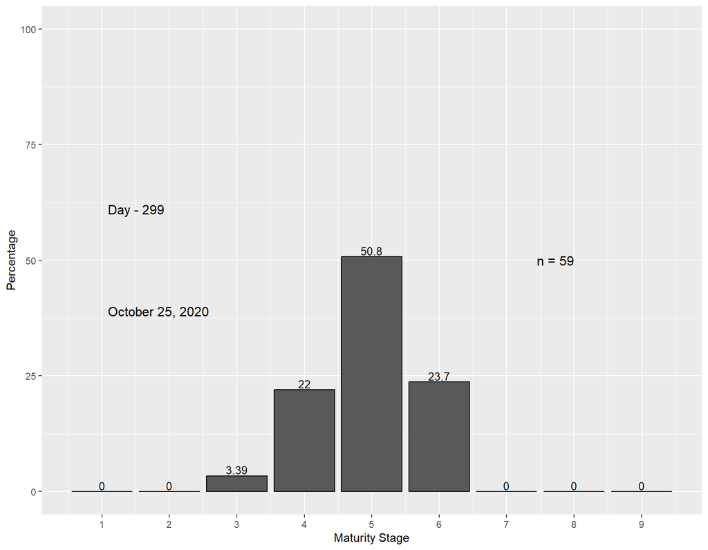

### Target Strength

|  | Location of survey | Interval (days) | Date | No. of Len. Samp. | No. of Det. Samp. | No. Len/Wt Fish | No. of Fish Measured | Mean Length (mm) | Mean Weight (g) | Target Strength (dB/kg) | Wt 28 cm Fish (g) | TS 28 cm Fish (dB/kg) |
| --- | --- | --- | --- | --- | --- | --- | --- | --- | --- | --- | --- | --- |
| 1 | German Bank #1 |  | Aug - 16 | 6 | 2 | 45 | 1121 | 248 | 114 | -34.5791 | 174 | -35.3509 |
| 2 | German Bank #2 | 15 | Aug - 31 | 20 | 5 | 122 | 3770 | 272 | 164 | -35.3465 | 180 | -35.5195 |
| 3 | German Bank #3 | 13 | Sep - 13 | 23 | 4 | 97 | 4215 | 263 | 145 | -35.1087 | 179 | -35.4762 |
| 4 | German Bank #4 | 14 | Sep - 27 | 17 | 5 | 135 | 3230 | 278 | 170 | -35.33 | 174 | -35.3679 |
| 5 | German Bank #5 | 14 | Oct - 11 | 15 | 3 | 76 | 2641 | 270 | 154 | -35.1472 | 173 | -35.3435 |
| 6 | German Bank #6 | 14 | Oct - 25 | 8 | 2 | 59 | 1312 | 270 | 145 | -34.893 | 163 | -35.0829 |

| Location of survey | Interval (days) | Date | No. of Len. Samp. | No. of Det. Samp. | No. Len/Wt Fish | No. of Fish Measured | Mean Length (mm) | Mean Weight (g) | Target Strength (dB/kg) | Wt 28 cm Fish (g) | TS 28 cm Fish (dB/kg) |
| --- | --- | --- | --- | --- | --- | --- | --- | --- | --- | --- | --- |
| German Bank #1 |  | Aug - 16 | 6 | 2 | 45 | 1121 | 248 | 114 | -34.5791 | 174 | -35.3509 |
| German Bank #2 | 15 | Aug - 31 | 20 | 5 | 122 | 3770 | 272 | 164 | -35.3465 | 180 | -35.5195 |
| German Bank #3 | 13 | Sep - 13 | 23 | 4 | 97 | 4215 | 263 | 145 | -35.1087 | 179 | -35.4762 |
| German Bank #4 | 14 | Sep - 27 | 17 | 5 | 135 | 3230 | 278 | 170 | -35.3300 | 174 | -35.3679 |
| German Bank #5 | 14 | Oct - 11 | 15 | 3 | 76 | 2641 | 270 | 154 | -35.1472 | 173 | -35.3435 |
| German Bank #6 | 14 | Oct - 25 | 8 | 2 | 59 | 1312 | 270 | 145 | -34.8930 | 163 | -35.0829 |

### NASC Plots

NASC - Nautical Area Scattering Strength

Figure. Herring NASC’s by 2 nautical mile intervals during the 2020 German Bank acoustic surveys.

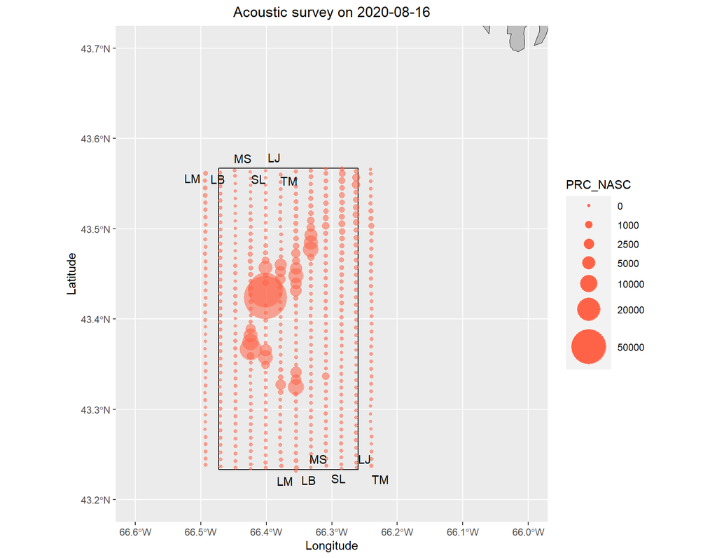

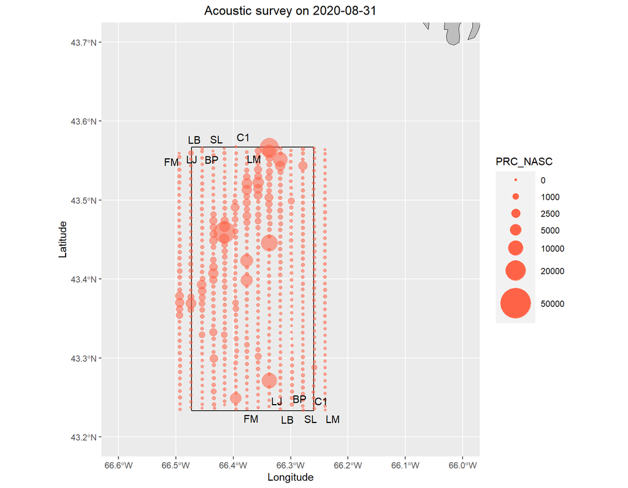

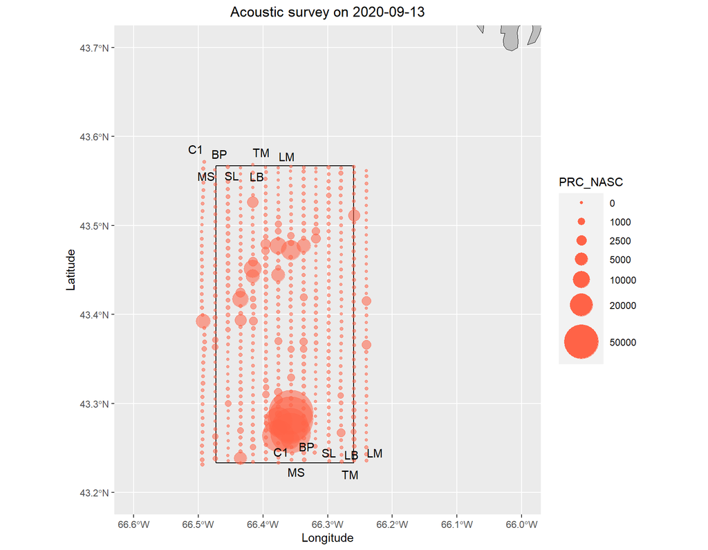

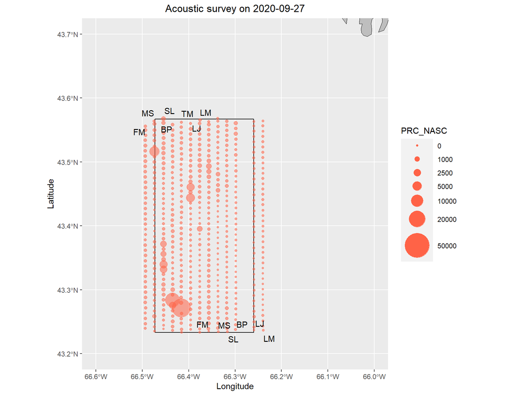

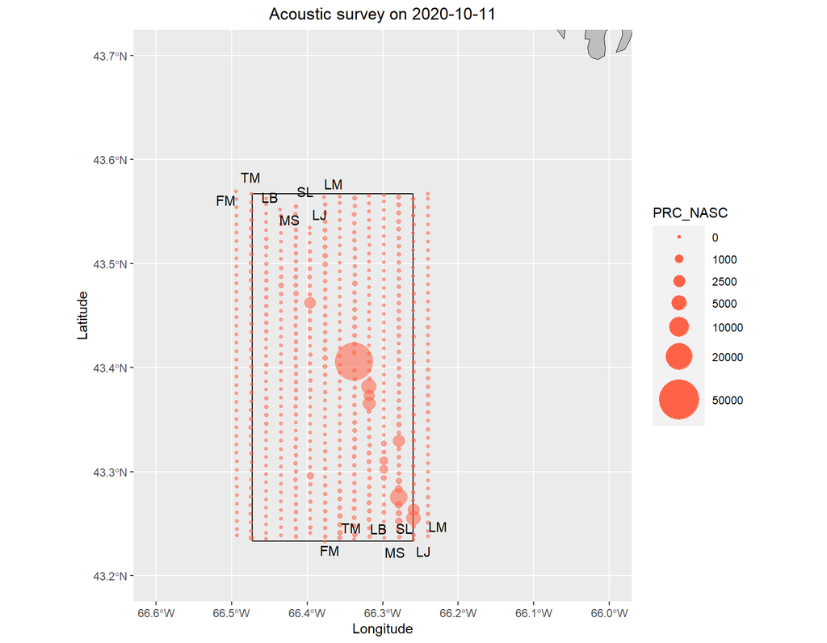

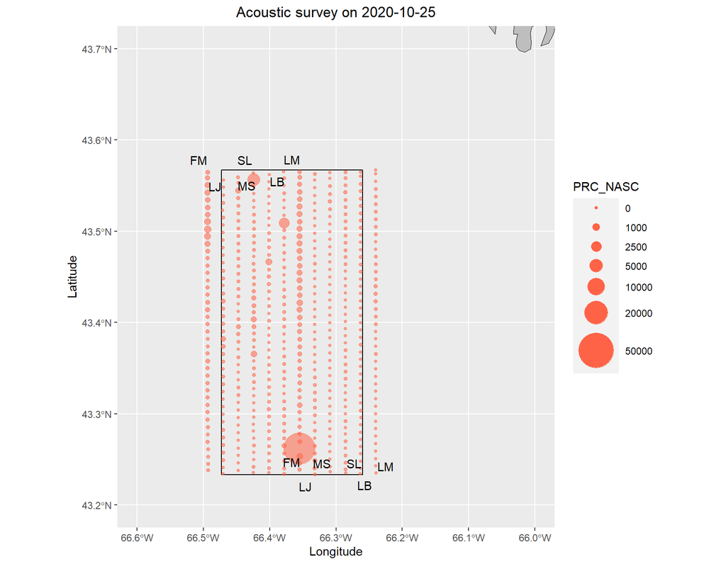

### SSB Bubble Plots

SSB - Spawning Stock Biomass

Work in Progress - Years with missing Bubbles have not been added to the database.

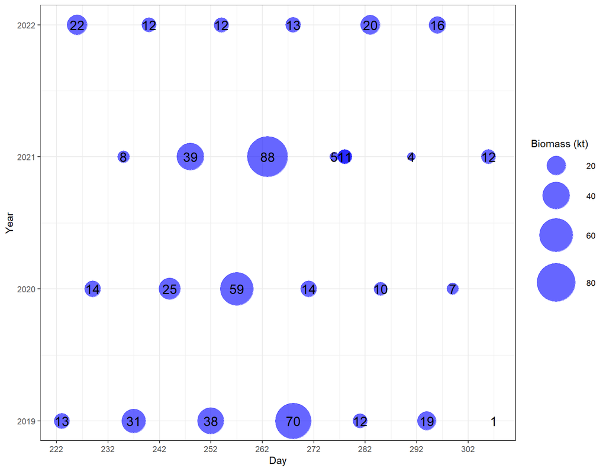

### adjusted SSB Bubble Plots

SSB - Spawning Stock Biomass

Figure. Spawning Stock Biomass (proportional to size of a bubble plot) in thousands from 1999 to 2022 German Bank acoustic survey by week number. SSB values were adjusted for turnover to decrease the chance of double counting. (0) indicates that a surveyed occurred, but due to double-counting these individuals were removed.

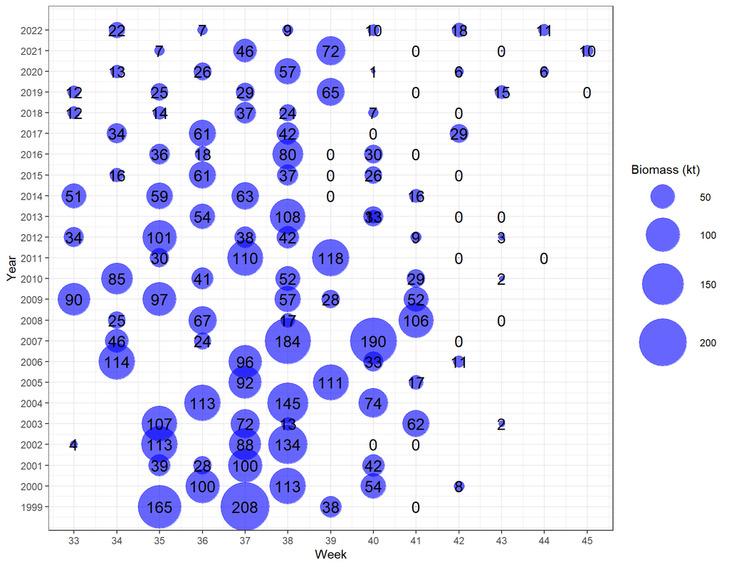

### Survey Details

|  | Location | Date | Transect Number | Target Strength (dB/kg) | Mean Sa (dB/m^2) | Distance (km) | Biomass Density kg/m^2 | Biomass (t) |
| --- | --- | --- | --- | --- | --- | --- | --- | --- |
| 1 | German | 2020-08-16 | LB_T01 | -34.5791 | -74.2592 | 38.777732128 | 0.001263116686008 | 88.5573690171771 |
| 2 | German | 2020-08-16 | LB_T02 | -34.5791 | -59.3574 | 38.290697174 | 0.039546842793334 | 2737.81386273054 |
| 3 | German | 2020-08-16 | LJ_T01 | -34.5791 | -51.3152 | 37.317527229 | 0.258530440323682 | 17443.0879735832 |
| 4 | German | 2020-08-16 | LJ_T02 | -34.5791 | -65.2588 | 36.994016249 | 0.0105179792548788 | 703.49759937348 |
| 5 | German | 2020-08-16 | LM_T01 | -34.5791 | -74.0913 | 37.607148656 | 0.00135379098396579 | 92.049376501964 |
| 6 | German | 2020-08-16 | LM_T02 | -34.5791 | -57.5103 | 37.958277262 | 0.0610398514715669 | 4189.08129762197 |
| 7 | German | 2020-08-16 | MS_T01 | -34.5791 | -74.6736 | 37.274321951 | 0.00119447412779738 | 80.4980437511953 |
| 8 | German | 2020-08-16 | MS_T02 | -34.5791 | -66.8086 | 37.077333814 | 0.00734483484333072 | 492.367477427722 |
| 9 | German | 2020-08-16 | SL_T01 | -34.5791 | -57.6476 | 40.807849752 | 0.0550108680281055 | 4058.73817424338 |
| 10 | German | 2020-08-16 | SL_T02 | -34.5791 | -65.4333 | 39.192037383 | 0.00953716231413085 | 675.796349689704 |

[output cut: 69 more lines]

| Location | Date | Transect Number | Target Strength (dB/kg) | Mean Sa (dB/m^2) | Distance (km) | Biomass Density kg/m^2 | Biomass (t) |
| --- | --- | --- | --- | --- | --- | --- | --- |
| German | 2020-08-16 | LB_T01 | -34.5791 | -74.2592 | 38.7777 | 0.0013 | 88.5574 |
| German | 2020-08-16 | LB_T02 | -34.5791 | -59.3574 | 38.2907 | 0.0395 | 2,737.8139 |
| German | 2020-08-16 | LJ_T01 | -34.5791 | -51.3152 | 37.3175 | 0.2585 | 17,443.0880 |
| German | 2020-08-16 | LJ_T02 | -34.5791 | -65.2588 | 36.9940 | 0.0105 | 703.4976 |
| German | 2020-08-16 | LM_T01 | -34.5791 | -74.0913 | 37.6071 | 0.0014 | 92.0494 |
| German | 2020-08-16 | LM_T02 | -34.5791 | -57.5103 | 37.9583 | 0.0610 | 4,189.0813 |
| German | 2020-08-16 | MS_T01 | -34.5791 | -74.6736 | 37.2743 | 0.0012 | 80.4980 |
| German | 2020-08-16 | MS_T02 | -34.5791 | -66.8086 | 37.0773 | 0.0073 | 492.3675 |
| German | 2020-08-16 | SL_T01 | -34.5791 | -57.6476 | 40.8078 | 0.0550 | 4,058.7382 |
| German | 2020-08-16 | SL_T02 | -34.5791 | -65.4333 | 39.1920 | 0.0095 | 675.7963 |
| German | 2020-08-16 | TM_T01 | -34.6864 | -61.8486 | 36.7612 | 0.0238 | 1,581.3075 |
| German | 2020-08-16 | TM_T02 | -34.6864 | -71.4761 | 36.9696 | 0.0026 | 172.2919 |

| Location | Date | Transect Number | Target Strength (dB/kg) | Mean Sa (dB/m^2) | Distance (km) | Biomass Density kg/m^2 | Biomass (t) |
| --- | --- | --- | --- | --- | --- | --- | --- |
| German | 2020-08-31 | BP_T01 | -34.8908 | -60.2443 | 36.4178 | 0.0426 | 2,375.2648 |
| German | 2020-08-31 | BP_T02 | -34.8908 | -68.8457 | 36.4269 | 0.0059 | 327.7756 |
| German | 2020-08-31 | C1_T01 | -34.8908 | -62.1184 | 41.0115 | 0.0246 | 1,542.7725 |
| German | 2020-08-31 | C1_T02 | -34.8908 | -70.1933 | 39.5259 | 0.0040 | 240.3310 |
| German | 2020-08-31 | FM_T01 | -34.8908 | -63.4513 | 37.7930 | 0.0196 | 1,135.0435 |
| German | 2020-08-31 | FM_T02 | -34.8908 | -60.7239 | 37.7504 | 0.0368 | 2,126.9189 |
| German | 2020-08-31 | LB_T01 | -34.8908 | -63.3966 | 38.2487 | 0.0196 | 1,149.4361 |
| German | 2020-08-31 | LB_T02 | -34.8908 | -60.8759 | 37.9773 | 0.0353 | 2,053.7917 |
| German | 2020-08-31 | LJ_T01 | -34.8908 | -64.3130 | 36.6383 | 0.0166 | 930.7825 |
| German | 2020-08-31 | LJ_T02 | -34.8908 | -57.1090 | 37.1326 | 0.0860 | 4,889.2547 |
| German | 2020-08-31 | LM_T01 | -34.8908 | -59.0142 | 37.4791 | 0.0550 | 3,152.9837 |
| German | 2020-08-31 | LM_T02 | -34.8908 | -71.8293 | 37.2809 | 0.0029 | 164.8989 |
| German | 2020-08-31 | SL_T01 | -34.8908 | -57.7987 | 39.4357 | 0.0691 | 4,171.3660 |
| German | 2020-08-31 | SL_T02 | -34.8908 | -66.4491 | 39.3230 | 0.0095 | 569.1541 |

| Location | Date | Transect Number | Target Strength (dB/kg) | Mean Sa (dB/m^2) | Distance (km) | Biomass Density kg/m^2 | Biomass (t) |
| --- | --- | --- | --- | --- | --- | --- | --- |
| German | 2020-09-13 | BP_T01 | -35.1087 | -69.6162 | 37.3561 | 0.0051 | 289.8403 |
| German | 2020-09-13 | BP_T02 | -35.1087 | -67.0788 | 36.0217 | 0.0094 | 519.8712 |
| German | 2020-09-13 | C1_T01 | -35.1087 | -64.6712 | 41.0028 | 0.0144 | 905.0247 |
| German | 2020-09-13 | C1_T02 | -35.1087 | -48.6870 | 38.9600 | 0.5999 | 35,898.5395 |
| German | 2020-09-13 | LB_T01 | -35.1087 | -64.8489 | 38.0560 | 0.0149 | 868.7314 |
| German | 2020-09-13 | LB_T02 | -35.1087 | -65.6554 | 38.5081 | 0.0122 | 721.5110 |
| German | 2020-09-13 | LM_T01 | -35.1087 | -53.5854 | 37.7315 | 0.2005 | 11,620.8377 |
| German | 2020-09-13 | LM_T02 | -35.1087 | -67.2849 | 37.1208 | 0.0087 | 495.7851 |
| German | 2020-09-13 | MS_T01 | -35.1087 | -70.0446 | 36.9522 | 0.0046 | 262.6166 |
| German | 2020-09-13 | MS_T02 | -35.1087 | -62.9920 | 36.9817 | 0.0235 | 1,332.2483 |
| German | 2020-09-13 | SL_T01 | -35.1087 | -60.6267 | 39.6838 | 0.0377 | 2,296.7463 |
| German | 2020-09-13 | SL_T02 | -35.1087 | -71.8857 | 39.1520 | 0.0029 | 171.8725 |
| German | 2020-09-13 | TM_T01 | -35.2160 | -59.4836 | 37.9127 | 0.0526 | 3,063.0128 |
| German | 2020-09-13 | TM_T02 | -35.2160 | -69.4702 | 37.3032 | 0.0054 | 307.2456 |

| Location | Date | Transect Number | Target Strength (dB/kg) | Mean Sa (dB/m^2) | Distance (km) | Biomass Density kg/m^2 | Biomass (t) |
| --- | --- | --- | --- | --- | --- | --- | --- |
| German | 2020-09-27 | BP_T01 | -35.3300 | -60.1524 | 36.4710 | 0.0437 | 2,688.4010 |
| German | 2020-09-27 | BP_T02 | -35.3300 | -70.8795 | 36.6426 | 0.0037 | 227.3966 |
| German | 2020-09-27 | FM_T01 | -35.3300 | -66.2879 | 36.4364 | 0.0106 | 654.5527 |
| German | 2020-09-27 | FM_T02 | -35.3300 | -64.6797 | 37.0597 | 0.0152 | 947.9140 |
| German | 2020-09-27 | LJ_T01 | -35.3300 | -63.2621 | 36.5131 | 0.0213 | 1,313.7804 |
| German | 2020-09-27 | LJ_T02 | -35.3300 | -73.6492 | 36.7998 | 0.0019 | 120.1757 |
| German | 2020-09-27 | LM_T01 | -35.3300 | -66.8053 | 37.5269 | 0.0092 | 581.0476 |
| German | 2020-09-27 | LM_T02 | -35.3300 | -73.8708 | 37.4521 | 0.0018 | 114.1986 |
| German | 2020-09-27 | MS_T01 | -35.3300 | -63.7887 | 37.0325 | 0.0186 | 1,163.7634 |
| German | 2020-09-27 | MS_T02 | -35.3300 | -69.3875 | 37.2976 | 0.0051 | 320.6143 |
| German | 2020-09-27 | SL_T01 | -35.3300 | -61.6140 | 38.8346 | 0.0293 | 1,920.1581 |
| German | 2020-09-27 | SL_T02 | -35.3300 | -70.0025 | 38.7327 | 0.0043 | 278.2835 |
| German | 2020-09-27 | TM_T01 | -35.4372 | -58.7241 | 36.9768 | 0.0614 | 3,828.7546 |

| Location | Date | Transect Number | Target Strength (dB/kg) | Mean Sa (dB/m^2) | Distance (km) | Biomass Density kg/m^2 | Biomass (t) |
| --- | --- | --- | --- | --- | --- | --- | --- |
| German | 2020-10-11 | FM_T01 | -35.1472 | -Inf | 38.1167 | 0.0000 | 0.0000 |
| German | 2020-10-11 | FM_T02 | -35.1472 | -77.4023 | 37.7683 | 0.0008 | 48.5597 |
| German | 2020-10-11 | LB_T01 | -35.1472 | -78.9699 | 38.1236 | 0.0006 | 33.8474 |
| German | 2020-10-11 | LB_T02 | -35.1472 | -63.4142 | 38.6277 | 0.0202 | 1,216.4286 |
| German | 2020-10-11 | LJ_T01 | -35.1472 | -68.9626 | 33.0453 | 0.0066 | 339.0434 |
| German | 2020-10-11 | LJ_T02 | -35.1472 | -65.0408 | 37.0095 | 0.0145 | 836.4297 |
| German | 2020-10-11 | LM_T01 | -35.1472 | -74.1893 | 37.8094 | 0.0017 | 101.7614 |
| German | 2020-10-11 | LM_T02 | -35.1472 | -79.8205 | 37.4414 | 0.0005 | 27.8266 |
| German | 2020-10-11 | MS_T01 | -35.1472 | -80.1623 | 35.5068 | 0.0005 | 25.7205 |
| German | 2020-10-11 | MS_T02 | -35.1472 | -70.2112 | 37.2160 | 0.0044 | 254.3263 |
| German | 2020-10-11 | SL_T01 | -35.1472 | -75.2621 | 38.7926 | 0.0013 | 79.4886 |
| German | 2020-10-11 | SL_T02 | -35.1472 | -62.7020 | 39.6509 | 0.0232 | 1,433.2011 |
| German | 2020-10-11 | TM_T01 | -35.2545 | -77.8781 | 37.5140 | 0.0008 | 44.6093 |
| German | 2020-10-11 | TM_T02 | -35.2545 | -56.8955 | 36.8698 | 0.0973 | 5,593.5007 |

| Location | Date | Transect Number | Target Strength (dB/kg) | Mean Sa (dB/m^2) | Distance (km) | Biomass Density kg/m^2 | Biomass (t) |
| --- | --- | --- | --- | --- | --- | --- | --- |
| German | 2020-10-25 | FM_T01 | -34.893 | -65.8069 | 38.2252 | 0.0097 | 667.8170 |
| German | 2020-10-25 | FM_T02 | -34.893 | -56.9110 | 37.9533 | 0.0755 | 5,178.9497 |
| German | 2020-10-25 | LB_T01 | -34.893 | -72.2796 | 38.0188 | 0.0022 | 150.4462 |
| German | 2020-10-25 | LB_T02 | -34.893 | -79.7105 | 38.6184 | 0.0004 | 27.1826 |
| German | 2020-10-25 | LJ_T01 | -34.893 | -74.3347 | 36.7709 | 0.0014 | 93.7291 |
| German | 2020-10-25 | LJ_T02 | -34.893 | -77.0612 | 37.3594 | 0.0007 | 50.0291 |
| German | 2020-10-25 | LM_T01 | -34.893 | -68.3541 | 38.1082 | 0.0054 | 371.4809 |
| German | 2020-10-25 | LM_T02 | -34.893 | -77.5473 | 37.9945 | 0.0007 | 44.7314 |
| German | 2020-10-25 | MS_T01 | -34.893 | -73.3595 | 36.4849 | 0.0018 | 117.3266 |
| German | 2020-10-25 | MS_T02 | -34.893 | -84.6398 | 36.9528 | 0.0001 | 8.7371 |
| German | 2020-10-25 | SL_T01 | -34.893 | -65.4635 | 40.3702 | 0.0099 | 722.7680 |
| German | 2020-10-25 | SL_T02 | -34.893 | -76.9539 | 39.4370 | 0.0007 | 51.2813 |

### Notes

No additional notes for this area.

## Seal Island

### Summary

Table. Summary of the 2020 Seal Island spawning ground acoustic survey data and associated biomass estimates.

|  | Location | Date | Interval (Days) | Target Strength (dB/kg) | Area (km<sup>2</sup>) | Mean Sa (dB/m<sup>2</sup>) | Biomass (t) | Standard Error (t) | St. Err % |
| --- | --- | --- | --- | --- | --- | --- | --- | --- | --- |
| 1 | Seal Island #1 | 2020-08-16 |  | -35.5 | 362 | -62.57 | 711 | 296 | 42 |
| 2 | Seal Island #2 | 2020-08-31 | 15 | -35.5 | 188 | -63.36 | 308 | 69 | 22 |
| 3 | Seal Island #3 | 2020-09-13 | 13 | -35.5 | 359 | -63.13 | 618 | 276 | 45 |
| 4 | Seal Island #4 | 2020-09-27 | 14 | -35.5 | 365 | -60.29 | 1211 | 171 | 14 |
| 5 | Seal Island #5 | 2020-10-11 | 14 | -35.5 | 354 | -63.03 | 625 | 253 | 40 |
| 6 | Seal Island #6 | 2020-10-26 | 15 | -35.5 | 370 | -61.86 | 857 | 465 | 54 |
| 7 | Summary |  |  |  | 333 | -62.37 | 4330 | 691 | 16 |

| Location | Date | Interval (Days) | Target Strength (dB/kg) | Area (km<sup>2</sup>) | Mean Sa (dB/m<sup>2</sup>) | Biomass (t) | Standard Error (t) | St. Err % |
| --- | --- | --- | --- | --- | --- | --- | --- | --- |
| Seal Island #1 | 2020-08-16 |  | -35.5 | 362 | -62.57 | 711 | 296 | 42 |
| Seal Island #2 | 2020-08-31 | 15 | -35.5 | 188 | -63.36 | 308 | 69 | 22 |
| Seal Island #3 | 2020-09-13 | 13 | -35.5 | 359 | -63.13 | 618 | 276 | 45 |
| Seal Island #4 | 2020-09-27 | 14 | -35.5 | 365 | -60.29 | 1,211 | 171 | 14 |
| Seal Island #5 | 2020-10-11 | 14 | -35.5 | 354 | -63.03 | 625 | 253 | 40 |
| Seal Island #6 | 2020-10-26 | 15 | -35.5 | 370 | -61.86 | 857 | 465 | 54 |
| Summary |  |  |  | 333 | -62.37 | 4,330 | 691 | 16 |

### Length Frequency

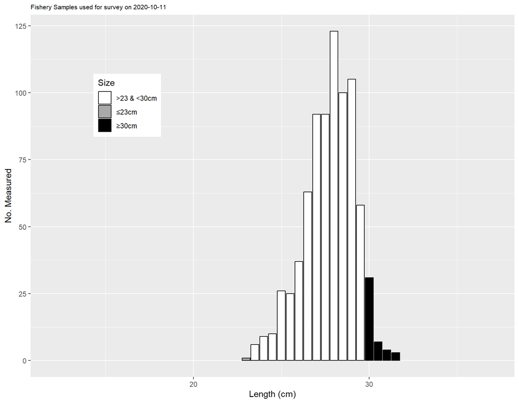

### Maturity Samples

Figure. Herring maturity samples collected during Seal Island surveys in 2020 to determine proportion of individuals spawning for Eastern Shore acoustic index of spawning stock biomass. Stage codes are: 1-2 Immature, 3-5 Ripening or Ripe. 6, Spawning, 7 Spent, and 8-9 Recovering.

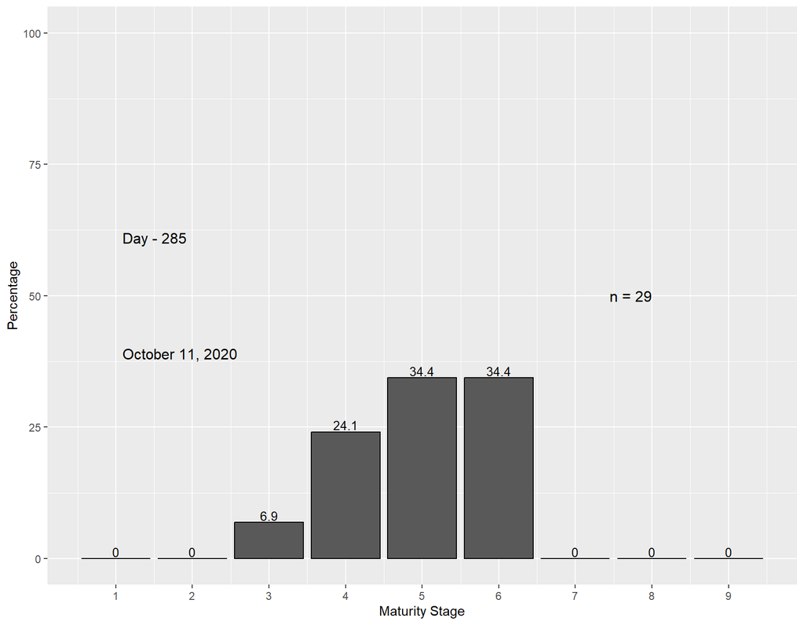

### Target Strength

Table. Summary of 2020 fish sampled for Seal Island by survey date and location with TS estimate from samples and TS estimate for a 28 cm herring using the length/weight equation.

|  | Location of survey | Interval (days) | Date | No. of Len. Samp. | No. of Det. Samp. | No. Len/Wt Fish | No. of Fish Measured | Mean Length (mm) | Mean Weight (g) | Target Strength (dB/kg) | Wt 28 cm Fish (g) | TS 28 cm Fish (dB/kg) |
| --- | --- | --- | --- | --- | --- | --- | --- | --- | --- | --- | --- | --- |
| 1 | Seal Island #1 |  | Aug - 16 |  |  |  |  |  |  | -35.5 |  |  |
| 2 | Seal Island #2 | 15 | Aug - 31 |  |  |  |  |  |  | -35.5 |  |  |
| 3 | Seal Island #3 | 13 | Sep - 13 |  |  |  |  |  |  | -35.5 |  |  |
| 4 | Seal Island #4 | 14 | Sep - 27 |  |  |  |  |  |  | -35.5 |  |  |
| 5 | Seal Island #5 | 14 | Oct - 11 | 4 | 1 | 29 | 792 | 272 | 154 | -35.0943 | 168 | -35.2115 |
| 6 | Seal Island #6 | 14 | Oct - 25 |  |  |  |  |  |  | -35.5 |  |  |

| Location of survey | Interval (days) | Date | No. of Len. Samp. | No. of Det. Samp. | No. Len/Wt Fish | No. of Fish Measured | Mean Length (mm) | Mean Weight (g) | Target Strength (dB/kg) | Wt 28 cm Fish (g) | TS 28 cm Fish (dB/kg) |
| --- | --- | --- | --- | --- | --- | --- | --- | --- | --- | --- | --- |
| Seal Island #1 |  | Aug - 16 |  |  |  |  |  |  | -35.5000 |  |  |
| Seal Island #2 | 15 | Aug - 31 |  |  |  |  |  |  | -35.5000 |  |  |
| Seal Island #3 | 13 | Sep - 13 |  |  |  |  |  |  | -35.5000 |  |  |
| Seal Island #4 | 14 | Sep - 27 |  |  |  |  |  |  | -35.5000 |  |  |
| Seal Island #5 | 14 | Oct - 11 | 4 | 1 | 29 | 792 | 272 | 154 | -35.0943 | 168 | -35.2115 |
| Seal Island #6 | 14 | Oct - 25 |  |  |  |  |  |  | -35.5000 |  |  |